# Test Matches Record

Bunty Patil

2024-03-15

### Installing and loading packages

To start with our report we need to install some of the packages as follows:

```r
install.packages("tidyverse", repos = "http://cran.us.r-project.org");
install.packages("janitor", repos = "http://cran.us.r-project.org")
```

Then load the packages:

```r
library(tidyverse)
library(janitor)
```

### Data Collection

The collection of raw data is the first step of the data analysis. The raw test matches record dataset is downloaded in csv format from the platform named **Kaggle** and stored in local drive.

To import the csv file, we use read_csv function

```r
test_matches <- read_csv("test_matches_records.csv")
```

```
## ──────────────────────────────────────────────────────── Delimiter: "," chr
## (8): Names, Country, Span, Matches, Highest Score, Fours, Balls_Faced, S... dbl
## (9): ...1, Innings, Not Outs, Total Runs, Average, Strike Rate, Hundreds...
```

### Data cleaning

Data cleaning is the process of fixing or removing incorrect, corrupted, incorrectly formatted, duplicate, or incomplete data within a dataset.

First lets get all columns name of our data

```r
colnames(test_matches)
```

```
##  [1] "...1"          "Names"         "Country"       "Span"
##  [5] "Matches"       "Innings"       "Not Outs"      "Total Runs"
##  [9] "Highest Score" "Average"       "Fours"         "Balls_Faced"
## [13] "Strike Rate"   "Hundreds"      "Fifty"         "Zeroes"
## [17] "Sixes"
```

As our output shows, first column is not valid and other columns are not properly named. To rename our column we use rename function as follows

```r
test_matches_records <- rename(test_matches, "sr_no" = "...1")
```

Now to name our all columns properly, we use clean_names() function

```r
test_matches_records <- clean_names(test_matches_records)
```

Now, lets check our values in all columns

```r
glimpse(test_matches_records)
```

```
## Rows: 107
## Columns: 17
## $ sr_no         <dbl> 0, 1, 2, 3, 4, 5, 6, 7, 8, 9, 10, 11, 12, 13, 14, 15, 16…
## $ names         <chr> "SR Tendulkar", "RT Ponting", "JH Kallis", "R Dravid", "…
## $ country       <chr> "IND", "AUS", "SA", "IND", "ENG", "SL", "WI", "WI", "SL"…
## $ span          <chr> "1989-2013", "1995-2012", "1995-2013", "1996-2012", "200…
## $ matches       <chr> "200", "168", "166", "164", "161", "134", "131", "164", …
## $ innings       <dbl> 329, 287, 280, 286, 291, 233, 232, 280, 252, 249, 265, 2…
## $ not_outs      <dbl> 33, 29, 40, 32, 16, 17, 6, 49, 15, 20, 44, 46, 16, 19, 2…
## $ total_runs    <dbl> 15921, 13378, 13289, 13288, 12472, 12400, 11953, 11867, …
## $ highest_score <chr> "248*", "257", "224", "270", "294", "319", "400*", "203*…
## $ average       <dbl> 53.78, 51.85, 55.37, 52.31, 45.35, 57.40, 52.88, 51.37, …
## $ fours         <chr> "2058+", "1509", "1488", "1654", "1442", "1491", "1559",…
## $ balls_faced   <chr> "29437+", "22782", "28903", "31258", "26562", "22882", "…
## $ strike_rate   <dbl> 54.04, 58.72, 45.97, 42.51, 46.95, 54.19, 60.51, 43.31, …
## $ hundreds      <dbl> 51, 41, 45, 36, 33, 38, 34, 30, 34, 30, 27, 32, 34, 34, …
## $ fifty         <dbl> 68, 62, 58, 63, 57, 52, 48, 66, 50, 60, 63, 50, 45, 33, …
## $ zeroes        <dbl> 14, 17, 16, 8, 9, 11, 17, 15, 15, 12, 11, 22, 12, 19, 9,…
## $ sixes         <chr> "69", "73", "97", "21", "11", "51", "88", "36", "61", "4…
```

As we can see from the output that our sr no is starting from 0 instead of 1. To fix this

```r
test_matches_records$sr_no <- test_matches_records$sr_no + 1
```

Also, there are special characters like ’*’ and ‘+’ in matches, balls_faced, fours and sixes column. To remove it

```r
testmatches <- test_matches_records %>%
  mutate(
    matches = as.numeric(str_remove(matches, "[*+]")),
    fours = as.numeric(str_remove(fours, "[*+]")),
    sixes = as.numeric(str_remove(sixes, "[*+]")),
    balls_faced = as.numeric(str_remove(balls_faced, "[*+]"))
    )
```

Lets check the result

```r
head(testmatches)
```

```
## # A tibble: 6 × 17
##   sr_no names    country span  matches innings not_outs total_runs highest_score
##   <dbl> <chr>    <chr>   <chr>   <dbl>   <dbl>    <dbl>      <dbl> <chr>
## 1     1 SR Tend… IND     1989…     200     329       33      15921 248*
## 2     2 RT Pont… AUS     1995…     168     287       29      13378 257
## 3     3 JH Kall… SA      1995…     166     280       40      13289 224
## 4     4 R Dravid IND     1996…     164     286       32      13288 270
## 5     5 AN Cook  ENG     2006…     161     291       16      12472 294
## 6     6 KC Sang… SL      2000…     134     233       17      12400 319
## # ℹ 8 more variables: average <dbl>, fours <dbl>, balls_faced <dbl>,
## #   strike_rate <dbl>, hundreds <dbl>, fifty <dbl>, zeroes <dbl>, sixes <dbl>
```

Now lets check the duplicates in our data

```r
get_dupes(testmatches)
```

```
## No variable names specified - using all columns.
```

```
## No duplicate combinations found of: sr_no, names, country, span, matches, innings, not_outs, total_runs, highest_score, ... and 8 other variables
```

```
## # A tibble: 0 × 18
## # ℹ 18 variables: sr_no <dbl>, names <chr>, country <chr>, span <chr>,
## #   matches <dbl>, innings <dbl>, not_outs <dbl>, total_runs <dbl>,
## #   highest_score <chr>, average <dbl>, fours <dbl>, balls_faced <dbl>,
## #   strike_rate <dbl>, hundreds <dbl>, fifty <dbl>, zeroes <dbl>, sixes <dbl>,
## #   dupe_count <int>
```

There are no duplicates in our data.

### Data organization

Data organization is a process of organizing raw data, by classifying them into different categories.

Now we want to seperate years from span column into ‘from’ and ‘to’ column for our easy analysis

```r
test_matches_clean <- separate(testmatches, col = span,
                               into = c("from", "to"), sep = "-")
```

Changing data type of ‘from’ and ‘to’ columns to numeric data type

```r
test_matches_clean$to <- as.numeric(as.character(test_matches_clean$to))
test_matches_clean$from <- as.numeric(as.character(test_matches_clean$from))
```

```r
colnames(test_matches_clean)
```

```
##  [1] "sr_no"         "names"         "country"       "from"
##  [5] "to"            "matches"       "innings"       "not_outs"
##  [9] "total_runs"    "highest_score" "average"       "fours"
## [13] "balls_faced"   "strike_rate"   "hundreds"      "fifty"
## [17] "zeroes"        "sixes"
```

### Data Analysis

Lets start with our calculation and finding answers to our questions.

**Which are the test matches playing countries**

```r
test_matches_clean %>%
  distinct(country)
```

```
## # A tibble: 9 × 1
##   country
##   <chr>
## 1 IND
## 2 AUS
## 3 SA
## 4 ENG
## 5 SL
## 6 WI
## 7 PAK
## 8 NZ
## 9 BAN
```

There are total 9 test cricket playing countries.

**Total Matches played by each country**

```r
matches_played_by_country <- test_matches_clean %>%
  group_by(country) %>%
  summarise(total_matches = sum(matches)) %>%
  arrange(desc(total_matches))
print(matches_played_by_country)
```

```
## # A tibble: 9 × 2
##   country total_matches
##   <chr>           <dbl>
## 1 ENG              2439
## 2 AUS              2127
## 3 IND              1578
## 4 WI               1389
## 5 SL               1110
## 6 SA                945
## 7 PAK               805
## 8 NZ                655
## 9 BAN               158
```

Visualization:

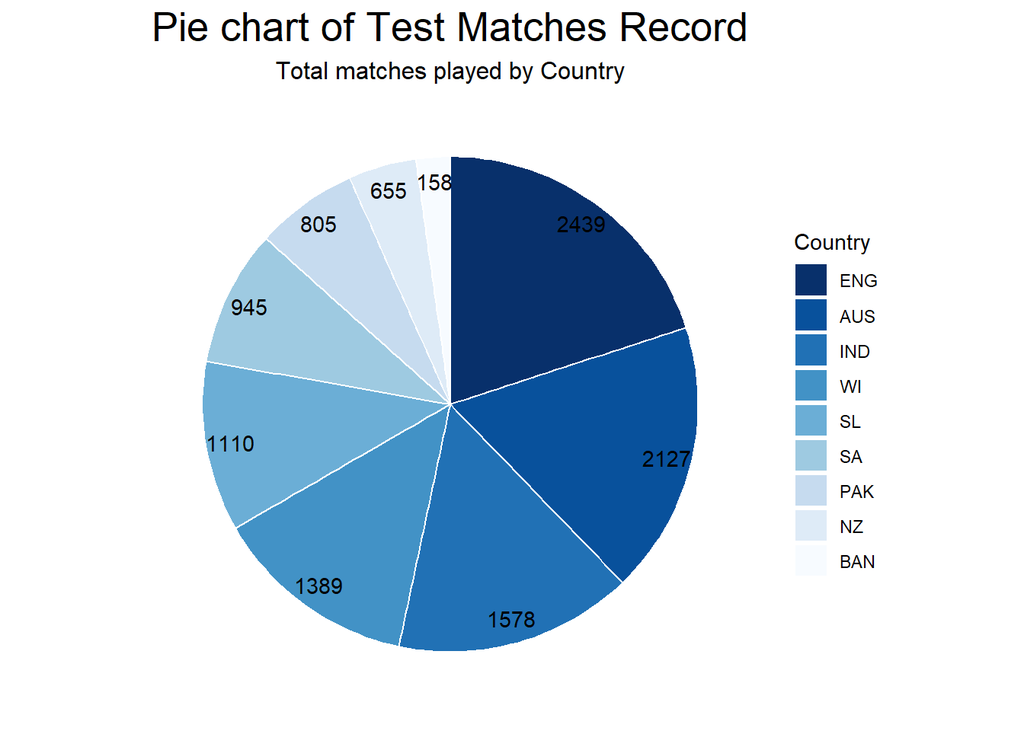

```r
matches_pie_chart <- matches_played_by_country %>%
  ggplot(aes(x = '', y = reorder(total_matches, country ) ,
             fill = factor(reorder(country, total_matches)) )) +
  geom_bar(stat = "identity", width = 1, color = 'white') +
  geom_text(aes(x = 1.4,label = total_matches),
            position =  position_stack(vjust= 0.5), color = 'black') +
  theme_void() +
  theme_classic() +
  theme(legend.position = "right") +
  coord_polar("y", start = 0)  +
  theme(plot.title = element_text(hjust = 0.5, size = 20)) +
  theme(plot.subtitle = element_text(hjust = 0.5, size = 12)) +
  theme(axis.line = element_blank()) +
  theme(axis.text = element_blank()) +
  theme(axis.ticks = element_blank()) +
  guides(fill = guide_legend(reverse = TRUE)) +
  labs(x = NULL, y = NULL,
       title = 'Pie chart of Test Matches Record',
       subtitle = 'Total matches played by Country') +
  scale_fill_brewer(palette = "Blues", name = "Country")
print(matches_pie_chart)
```

**Total players in each country**

```r
players_in_country <- test_matches_clean %>%
  group_by(country) %>%
  summarise(players_count = n()) %>%
  arrange(desc(players_count))
print(players_in_country)
```

```
## # A tibble: 9 × 2
##   country players_count
##   <chr>           <int>
## 1 ENG                24
## 2 AUS                21
## 3 IND                13
## 4 WI                 13
## 5 SL                 11
## 6 PAK                 8
## 7 SA                  8
## 8 NZ                  7
## 9 BAN                 2
```

Visualization:

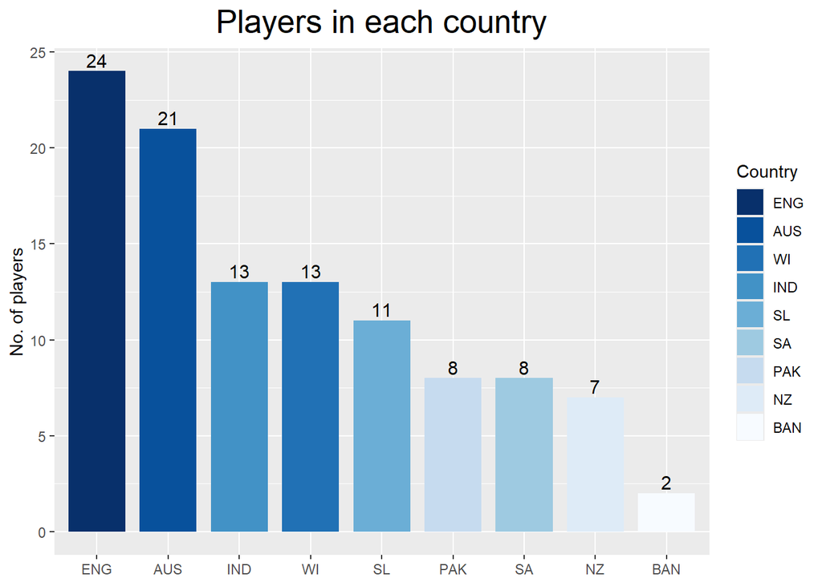

```r
players_bar_chart <-players_in_country %>%
  ggplot(aes(x = reorder(country, desc(players_count)),
             y = players_count,
             fill = factor(reorder(country, players_count)))) +
  geom_bar (stat="identity", width = 0.8) +
  geom_text(aes(label = players_count),
            vjust = -0.3, size = 4) +
  labs(title = "Players in each country",
       x= NULL, y="No. of players") +
  theme_get() +
  theme(plot.title = element_text(hjust = 0.5, size = 20)) +
  guides(fill = guide_legend(reverse = TRUE)) +
  scale_fill_brewer(palette = "Blues",
                    name = "Country")
print(players_bar_chart)
```

**Top 10 players with max runs and there highest scores**

```
## # A tibble: 10 × 3
##    names            total_runs highest_score
##    <chr>                 <dbl> <chr>
##  1 SR Tendulkar          15921 248*
##  2 RT Ponting            13378 257
##  3 JH Kallis             13289 224
##  4 R Dravid              13288 270
##  5 AN Cook               12472 294
##  6 KC Sangakkara         12400 319
##  7 BC Lara               11953 400*
##  8 S Chanderpaul         11867 203*
##  9 DPMD Jayawardene      11814 374
## 10 JE Root               11447 254
```

**Players from IND having max Average**

```
## # A tibble: 13 × 2
##    names         average
##    <chr>           <dbl>
##  1 SR Tendulkar     53.8
##  2 R Dravid         52.3
##  3 SM Gavaskar      51.1
##  4 V Sehwag         49.3
##  5 V Kohli          49.2
##  6 VVS Laxman       46.0
##  7 M Azharuddin     45.0
##  8 CA Pujara        43.6
##  9 SC Ganguly       42.2
## 10 DB Vengsarkar    42.1
## 11 GR Viswanath     41.9
## 12 AM Rahane        38.5
## 13 N Kapil Dev      31.0
```

**Players with max strike rate**

```
## # A tibble: 10 × 2
##    names         strike_rate
##    <chr>               <dbl>
##  1 V Sehwag             82.2
##  2 AC Gilchrist         82.0
##  3 N Kapil Dev          79.3
##  4 DA Warner            70.2
##  5 IVA Richards         69.8
##  6 TM Dilshan           65.5
##  7 ST Jayasuriya        65.2
##  8 BB McCullum          64.6
##  9 KP Pietersen         61.7
## 10 IT Botham            60.7
```

**Finding relation between Total Runs and Total Matches**

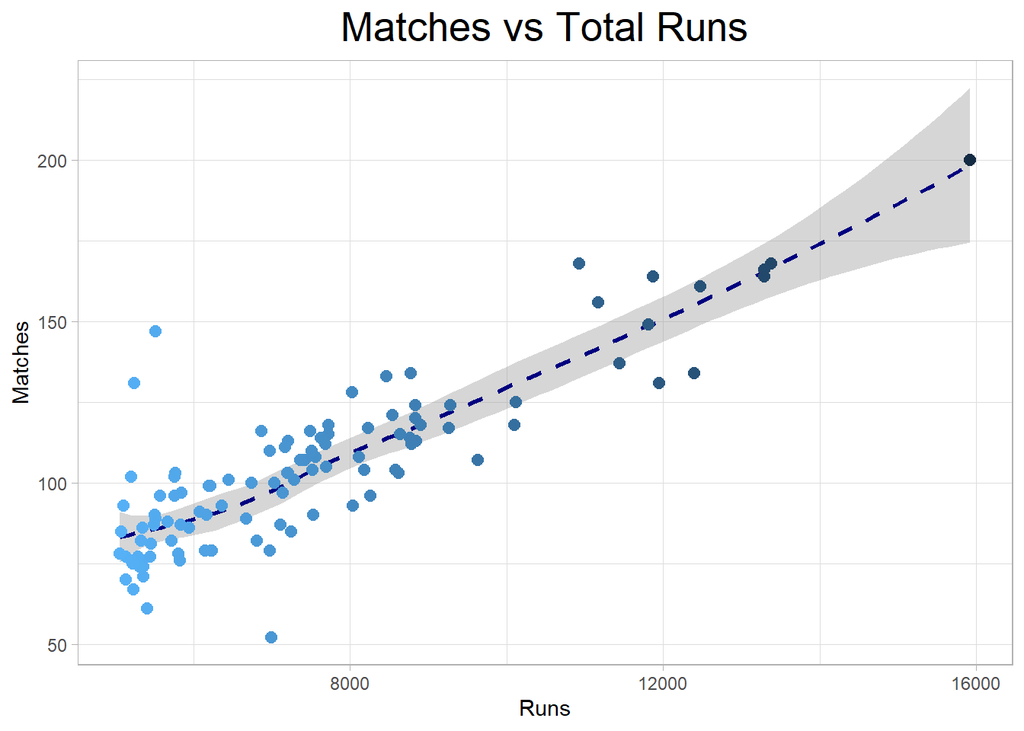

```r
runs_matches <- test_matches_clean %>%
  select(matches, total_runs, balls_faced) %>%
  ggplot(mapping = aes(x = total_runs, y = matches,
                       color = -total_runs)) +
  geom_smooth(formula = y ~ x, method = "loess",
              linetype = 'dashed', color = 'navy') +
  geom_point(size = 2.5) +
  labs(title = "Matches vs Total Runs",
       x = 'Runs', y = 'Matches')+
  theme_light() +
  theme(plot.title = element_text(hjust = 0.5, size = 20)) +
  theme(legend.position = "")
print(runs_matches)
```

**Players from India with max hundreds**

```
## # A tibble: 13 × 2
##    names         hundreds
##    <chr>            <dbl>
##  1 SR Tendulkar        51
##  2 R Dravid            36
##  3 SM Gavaskar         34
##  4 V Kohli             29
##  5 V Sehwag            23
##  6 M Azharuddin        22
##  7 CA Pujara           19
##  8 VVS Laxman          17
##  9 DB Vengsarkar       17
## 10 SC Ganguly          16
## 11 GR Viswanath        14
## 12 AM Rahane           12
## 13 N Kapil Dev          8
```

**Player with earliest debut**

```
## # A tibble: 5 × 2
##   names        from
##   <chr>       <dbl>
## 1 JB Hobbs     1908
## 2 WR Hammond   1927
## 3 DG Bradman   1928
## 4 L Hutton     1937
## 5 DCS Compton  1937
```

**Players with long career**

```r
test_matches_clean %>%
  select(names, from, to) %>%
  mutate(played_years = test_matches_clean$to - test_matches_clean$from) %>%
  arrange(desc(played_years))
```

```
## # A tibble: 107 × 4
##    names          from    to played_years
##    <chr>         <dbl> <dbl>        <dbl>
##  1 SR Tendulkar   1989  2013           24
##  2 JB Hobbs       1908  1930           22
##  3 S Chanderpaul  1994  2015           21
##  4 MC Cowdrey     1954  1975           21
##  5 GA Gooch       1975  1995           20
##  6 GS Sobers      1954  1974           20
##  7 WR Hammond     1927  1947           20
##  8 DG Bradman     1928  1948           20
##  9 DCS Compton    1937  1957           20
## 10 SR Waugh       1985  2004           19
## # ℹ 97 more rows
```

We have solved my questions with the dataset and can solve even more.